# 12. ttest: 2 groups

Masahiko Asano

2025-12-04

- `R packages we use in this section`

```r
library(tidyverse)
library(broom)
library(patchwork)
library(DT)
library(ggbeeswarm)
library(ggsignif)
library(rcompanion)
library(rmarkdown)
```

# 1. Why we conduct a `t-test`?

- A t-test is a statistical test that is used to compare the means of two groups.
- It is often used in hypothesis testing to determine whether a process or treatment actually has an effect on the population of interest, or whether two groups are different each other.
- The Central Limit Theorem suggests that even if the original variables themselves are not normally distributed, distribution of samples converges to normal as the number of samples increases.  
  → This is the theoretical foundation that we can conduct statistical inference and hypothesis test using a normal distribution.
- However, it is not always the case that we can have access to sizable data.
- t test provides us a solution of this small N problem in hypothesis testing.

# 2. What type of `t-test` should we use?

When you conduct a t-test, you need to consider two things:  
(1) whether the groups being compared come from a single population or two different populations  
(3) whether you want to test the difference in a specific direction or both directions

#### One-sample, two-sample, or paired `t-test`?

- If the groups come from a single population (for example, measuring before and after an medical treatment), perform a **paired t-test**.
- If the groups come from two different populations (for exmaple, comparing which hamberger tastes better between McDonald’s and In-N-Out Burger), perform a **two-sample t-test**.
- If there is one group being compared against a standard value (for example, comparing your test score to the averaged test score of your friends in the same class), perform a **one-sample t-test**.

#### One-tailed or two-tailed `t-test`?

- If you only care whether the two populations are different from one another, perform a **two-tailed t-test**.
- If you want to know whether one population mean is greater than or less than the other, perform a **one-tailed t-test**.
- A **one-tailed t-test** is way harder to be passed.

# 3. How to show results on `ttest`

- Four ways of showing the result of `ttest`

[figure not shown]

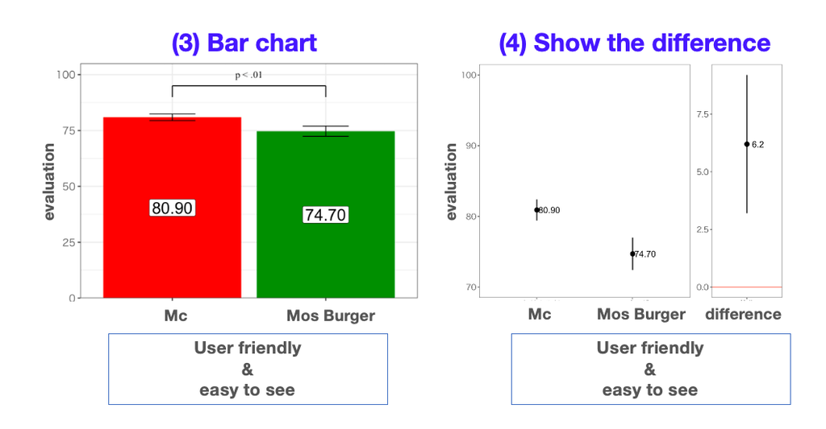

| **How to show the results** | **Features** |
| --- | --- |
| **(1) Simple output** | Rich info, but not easy to see |
| **(2) Boxplot/violin plot** | Easy to see the result & statistical significance |
| **(3) Bar chart** | easy to see |
| **(4) Show the difference** | Easy to see |

- **Researchers prefer to use (3) and (4) lately in academia**

# 4. Paired data

- `Paired-samples t-test`
- Respondents 1 to 10 (10 people) eat **both Mos burgers and Mc bergers**
- Respondents 1 to 10 (10 people) evaluate them in 0 - 100 scale.

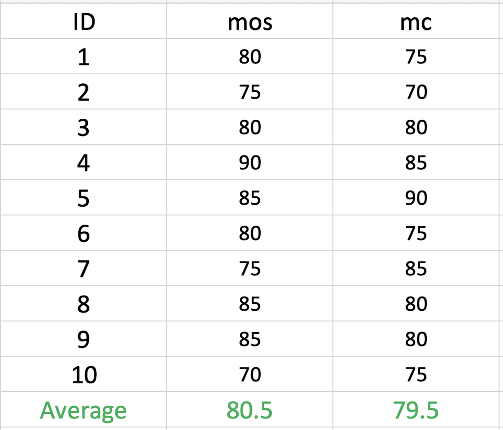

A sample: (`mos_mc.csv`)

- Sample means: mos (80.5), mc (79.5) => Mos is better
- **Is this also the case in the population?**
- We need to conduct `t-test` and confirm this.

## 4.1 Load `mos_mc.csv`

- Load the data: mos_mc.csv

```r
df_mos_mc <- read_csv("data/mos_mc_paired.csv")
```

- Check the data

```r
DT::datatable(df_mos_mc)
```

|  | mos | mc |
| --- | --- | --- |
| 1 | 80 | 75 |
| 2 | 75 | 70 |
| 3 | 80 | 80 |
| 4 | 90 | 85 |
| 5 | 85 | 90 |
| 6 | 80 | 75 |
| 7 | 75 | 85 |
| 8 | 85 | 80 |
| 9 | 85 | 80 |
| 10 | 70 | 75 |

- `mos_mc.csv` is called `wide format`
- `wide format` should be changed to `long format` in analyzing in R

## 4.2 Wide format => Long format

→ Using `tidyr::pivot_longer()` function, we change `mos_mc.csv` to `long format`

```r
df_long <- df_mos_mc %>%
    tidyr::pivot_longer(mos:mc,
                 names_to = "burger",
                 values_to = "score")
```

- Check `df_long`

```r
DT::datatable(df_long)
```

|  | burger | score |
| --- | --- | --- |
| 1 | mos | 80 |
| 2 | mc | 75 |
| 3 | mos | 75 |
| 4 | mc | 70 |
| 5 | mos | 80 |
| 6 | mc | 80 |
| 7 | mos | 90 |
| 8 | mc | 85 |
| 9 | mos | 85 |
| 10 | mc | 90 |

[output cut: 10 more lines]

## 4.3 Visualization

### 4.3.1 Boxplot

- In drawing a Box Plot, we use `long format` data

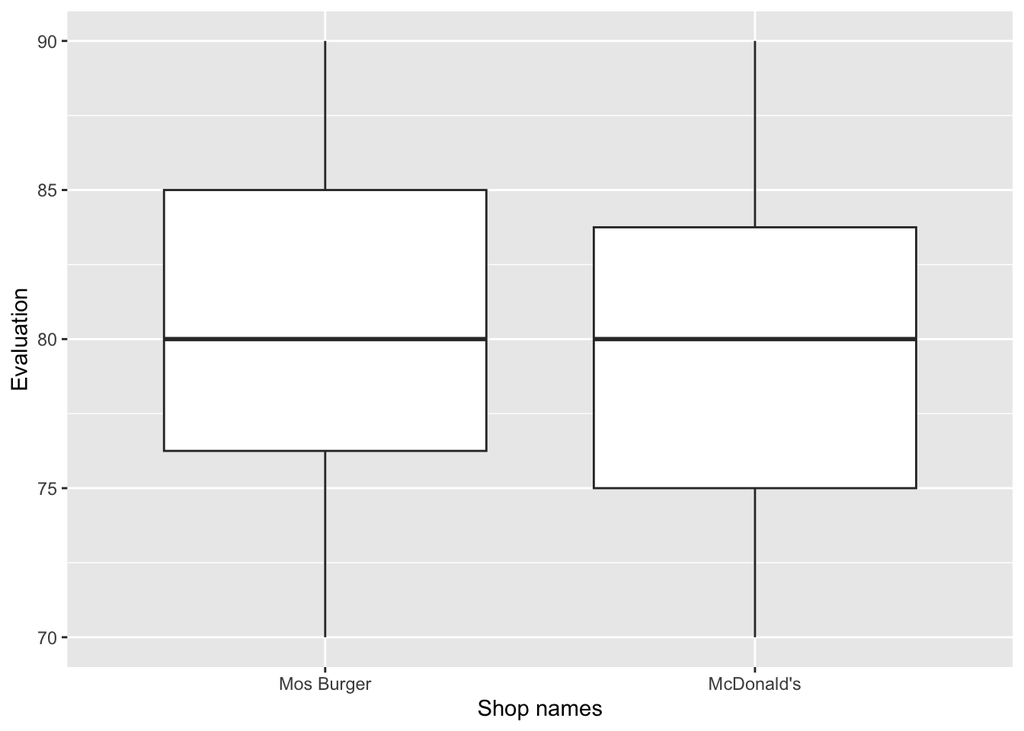

```r
df_long %>%
  mutate(burger = fct_inorder(burger)) %>%
  ggplot(aes(x = burger, y = score)) +
  geom_boxplot() +
  scale_x_discrete(labels = c( "Mos Burger", "McDonald's")) +
  labs(x = "Shop names", y = "Evaluation")
```

### 4.3.2 Violin Plot

- Violin Plot is similar to Box Plot
- Researchers tend to use Violin Plot more often than Box Plot

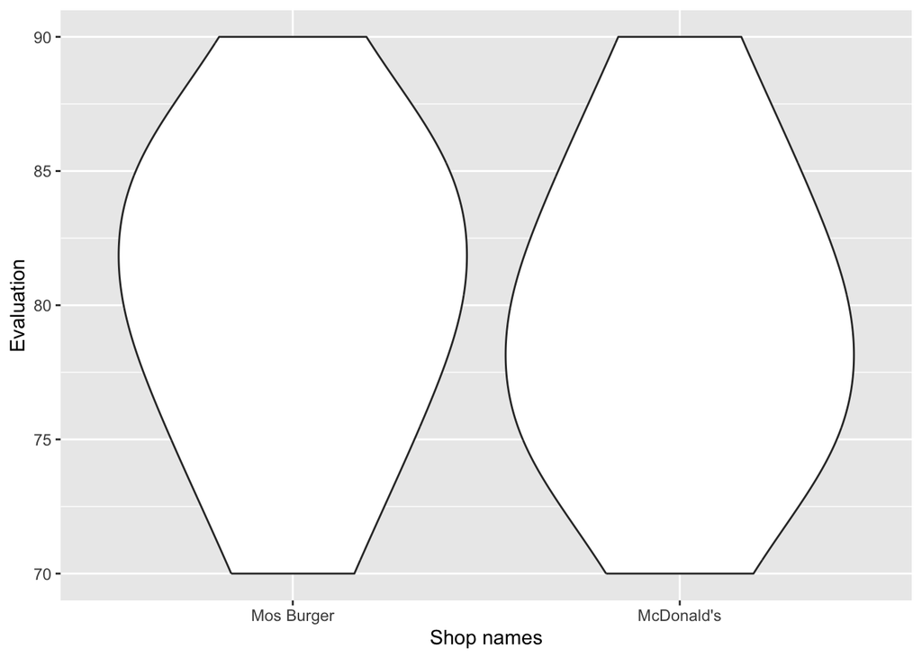

```r
df_long %>%
  mutate(burger = fct_inorder(burger)) %>%
  ggplot(aes(x = burger, y = score)) +
  geom_violin() +
  scale_x_discrete(labels = c( "Mos Burger", "McDonald's")) +
  labs(x = "Shop names", y = "Evaluation")
```

### 4.3.3 Box Plot + Violin Plot

- It is possible to simultaneously draw a Box Plot and Violin Plot

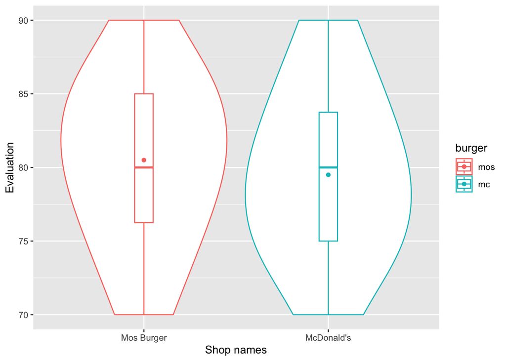

```r
df_long %>%
  mutate(burger = fct_inorder(burger)) %>%
  ggplot(aes(x = burger, y = score, color = burger)) +
  geom_violin() +
  geom_boxplot(width = .1) + # Set the width of Box Plot as 0.1
  stat_summary(fun.y = mean, geom = "point") + # Show the average as dots
  scale_x_discrete(labels = c( "Mos Burger", "McDonald's")) +
  labs(x = "Shop names", y = "Evaluation")
```

- Show the descriptive statistic of the data for Mos Burger and McDonald’s

```r
summary(df_mos_mc)
```

```
      mos              mc
 Min.   :70.00   Min.   :70.00
 1st Qu.:76.25   1st Qu.:75.00
 Median :80.00   Median :80.00
 Mean   :80.50   Mean   :79.50
 3rd Qu.:85.00   3rd Qu.:83.75
 Max.   :90.00   Max.   :90.00
```

- In this sample, we get the following results:
- Sample means: Mos (80.5), Mc (79.5) => Mos is better
- What we want to know:  
  => **Is this also the case in the population?**
- It may be a result we get by chance
- To confirm this, we need to conduct `paired ttest`

## 4.4 Process of t-test: by hand

Null hypothesis: $H_0$:  
There is no difference in tastes between McDonald’s and Mos Burger

Alternative hypothesis: $H_1$:  
There is a difference in tastes between McDonald’s and Mos Burger

Calculate `t-value`

Identify the critical value with which we reject the null hypothesis

Check if the `t-value` we get lies within the rejection area

Conclusion

**Equation for calculating t-value using Paired data**

$$T = \frac{\bar{d} - d_0}{u_x /
\sqrt{n}}$$
Where,

$$\bar{d} = \frac{\sum (x_i -
y_i)}{n}$$

```r
x <- df_mos_mc$mos
y <- df_mos_mc$mc
```

```r
d <- x - y
```

```r
t <- (mean(d) - 0) / (sd(d) / sqrt(10))
```

```r
t
```

```
[1] 0.557086
```

- This is the t-value (0.557086) we calculated by hand
- The following is the t-distribution table

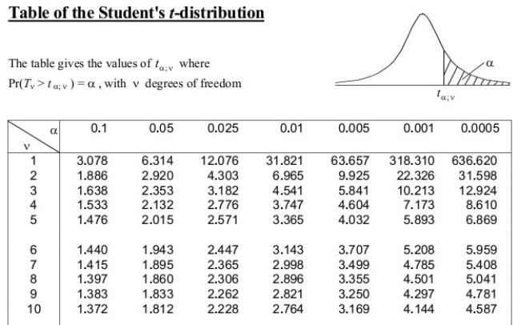

- Figures show the critical values corresponding to several **significance levels**
- Significance levels is shown as $α$
- When the t-value calculated with the sample data is larger than the critical value (you chose), then you reject the null hypothesis. - In this case, we want to know if there is difference (or not) between McDonald’s and Mos burger in tastes.
- It is common to use the significance level = 5%（$α = 0.05$).
- It is also common to use `two-paired` t-test (**because what we want to know is NOT McDonald’s is tastier than Mos Burger, or vise-verse**).  
  => What we want to know is whether McDonald’s burger is different from Mos Burger in tastes.  
  => We should use `two-paired` t-test.  
  => We should take a look at the cell with $α = 0.025$
- The number of cases we use in this comparison is 10  
  =>**degree of freedom (v) = 10 - 1 = 9**  
  => We should take a look at the cell between $α = 0.025$ and $v = 9$
- **2.262** is the critical value in conducting our t-test
- We have two critical values (`-2.262` & `2.262`)

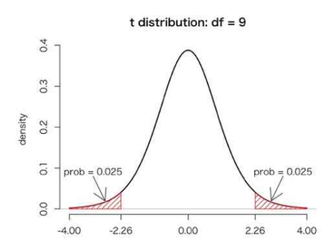

Interpretation ・**The t-value we calculated from our sample (0.557086)** lies in between -2.26 and 2.26  
=> We cannot reject the null hypothesis  
=> We cannot say anything about the difference between McDonald’s and Mos burger in tastes.  
・**The sample mean we get (Mos 80.5, Mc 79.5) from our sample are highly likely to gained by chance. This is not the case in population.**

## 4.5 Process of t-test: by R

### 4.5.1 In case you use `long format data`

- Let’s use the datafreame (`df_long`) we modified at Section 4.2
- Check `df_long`

```r
df_long
```

```
# A tibble: 20 × 2
   burger score
   <chr>  <dbl>
 1 mos       80
 2 mc        75
 3 mos       75
 4 mc        70
 5 mos       80
 6 mc        80
 7 mos       90
 8 mc        85
 9 mos       85
10 mc        90
11 mos       80
12 mc        75
13 mos       75
14 mc        85
15 mos       85
16 mc        80
17 mos       85
18 mc        80
19 mos       70
20 mc        75
```

- Conduct a t-test

```r
t.test(df_long$score[df_long$burger == "mos"],
       df_long$score[df_long$burger == "mc"]) # unpaired is default
```

```
    Welch Two Sample t-test

data:  df_long$score[df_long$burger == "mos"] and df_long$score[df_long$burger == "mc"]
t = 0.37354, df = 18, p-value = 0.7131
alternative hypothesis: true difference in means is not equal to 0
95 percent confidence interval:
 -4.624301  6.624301
sample estimates:
mean of x mean of y
     80.5      79.5
```

Interpretation ・Null Hypothesis:  
**There is no difference in tastes between McDonald’s and Mos Burger.**  
・See `t = 0.37354` in line 4  
**The p-value R calculated from our sample = 0.7131**  
=> We cannot reject the null hypothesis because **0.7131** is larger than **0.05**  
=> We cannot say anything about the difference between McDonald’s and Mos burger in tastes.  
・**The sample mean we get (Mos 80.5, Mc 79.5) from our sample are highly likely to gained by chance. This is not the case in population.**

- Using `ggsignif()` function, we can draw a boxplot with statistical significance, `p-value`
- `unpaired data` is default in `ggsignif()` function  
  → `test.args = list(paired = TRUE)`

test.arg( ) ・If you use paired data → `test.args = list(paired = TRUE)`  
・If you use unpaired data → `test.args = list(paired = FALSE)` or  
→ You don’t have to write this code.

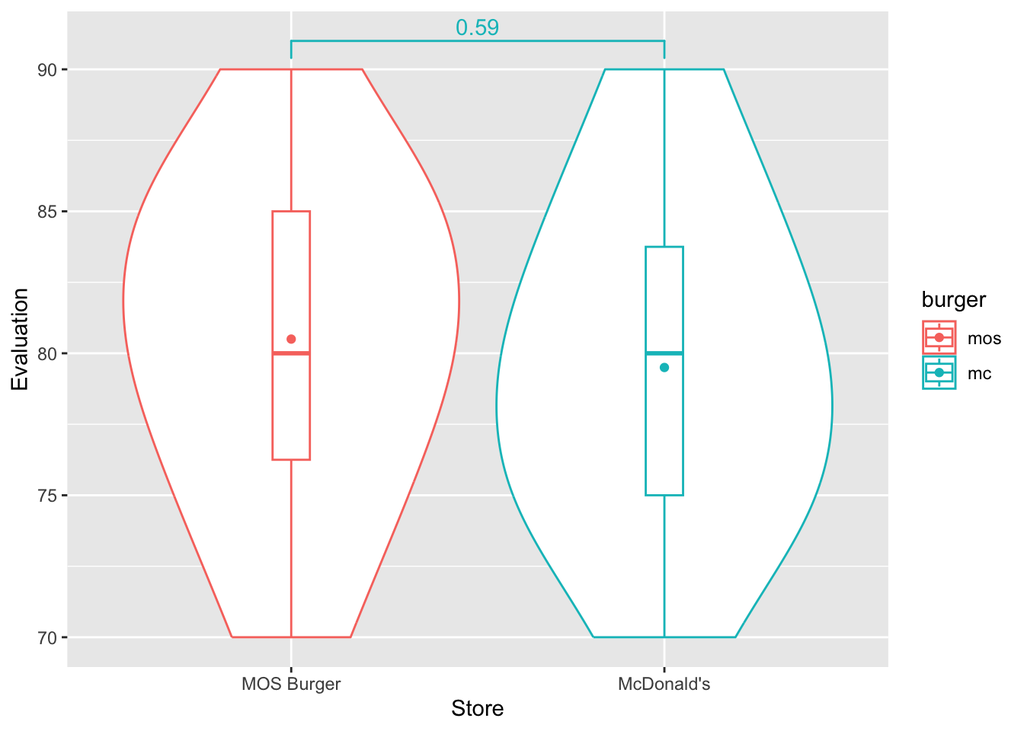

```r
df_long %>%
  mutate(burger = fct_inorder(burger)) %>%
  ggplot(aes(x = burger, y = score, color = burger)) +
  geom_violin() +
  geom_boxplot(width = .1) +
  stat_summary(fun.y = mean, geom = "point") +
  scale_x_discrete(labels = c( "MOS Burger", "McDonald's")) +
  labs(x = "Store", y = "Evaluation") +
    ggsignif::geom_signif(comparisons = combn(sort(unique(df_long$burger)), 2, FUN = list),
                          test = "t.test",
                          test.args = list(paired = TRUE),
                          na.rm = T,
                          step_increase = 0.1)
```

→ When you use `unpaired data`, then you delete `test.args = list(paired = TRUE)`

### 4.5.2 In case you use `wide format data`

```r
df_mos_mc
```

```
# A tibble: 10 × 2
     mos    mc
   <dbl> <dbl>
 1    80    75
 2    75    70
 3    80    80
 4    90    85
 5    85    90
 6    80    75
 7    75    85
 8    85    80
 9    85    80
10    70    75
```

```r
t.test(df_mos_mc$mos,
       df_mos_mc$mc,
       paired = TRUE)
```

```
    Paired t-test

data:  df_mos_mc$mos and df_mos_mc$mc
t = 0.55709, df = 9, p-value = 0.5911
alternative hypothesis: true mean difference is not equal to 0
95 percent confidence interval:
 -3.060696  5.060696
sample estimates:
mean difference
              1
```

### 4.5.3 t-test using `One Sample t-test`

```r
diff <- df_mos_mc$mos - df_mos_mc$mc
diff
```

```
 [1]   5   5   0   5  -5   5 -10   5   5  -5
```

- Calculate mean of `diff`

```r
mean(diff)
```

```
[1] 1
```

```r
t.test(diff)
```

```
    One Sample t-test

data:  diff
t = 0.55709, df = 9, p-value = 0.5911
alternative hypothesis: true mean is not equal to 0
95 percent confidence interval:
 -3.060696  5.060696
sample estimates:
mean of x
        1
```

# 5. Unpaired data

- `Unpaired-samples t-test`
- 20 people eat **either Mos Burgers or Mc burgers.**
- Respondents 1 to 10 eat Mos Burger.
- Respondents 11 to 20 eat McDonald’s burger.
- These 20 respondents evaluate them in 0 - 100 scale.

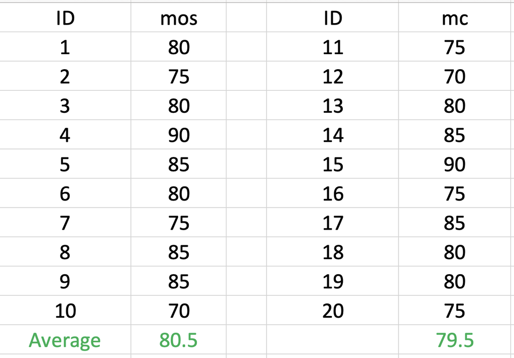

**A sample: (mos_mc.csv)**

- Sample means: Mos (80.5), Mc (79.5) => Mos is better
- **Is this also the case in the population?**
- We need to conduct `t-test` and confirm this.

#### Summary: `paired` and `unpaired` data

| **Type of data** | **Details** |
| --- | --- |
| **`Paired`** | 10 people eat both burgers |
| **`Unpaired`** | 10 people eat Mos and the other 10 people eat Mc burgers |

## 5.1 `mos_mc_paired.csv`

- Load the data: [mos_mc_paired.csv](http://www.ner.takushoku-u.ac.jp/masano/class_material/waseda/keiryo/Data/mos_mc_paird.csv)

```r
df_mos_mc_paired <- read_csv("data/mos_mc_paired.csv")
```

- Check the data

```r
DT::datatable(df_mos_mc_paired)
```

|  | mos | mc |
| --- | --- | --- |
| 1 | 80 | 75 |
| 2 | 75 | 70 |
| 3 | 80 | 80 |
| 4 | 90 | 85 |
| 5 | 85 | 90 |
| 6 | 80 | 75 |
| 7 | 75 | 85 |
| 8 | 85 | 80 |
| 9 | 85 | 80 |
| 10 | 70 | 75 |

## 5.2 Wide format => Long format

- `mos_mc_paired.csv` is called `wide format`
- `wide format` should be changed to `long format` in R  
  → Using `tidyr::pivot_longer()` function, we change `mos_mc.csv` to `long format`

```r
df_long <- df_mos_mc_paired %>%
    tidyr::pivot_longer(mos:mc,
                 names_to = "burger",
                 values_to = "score")
```

- Check df_long

```r
DT::datatable(df_long)
```

|  | burger | score |
| --- | --- | --- |
| 1 | mos | 80 |
| 2 | mc | 75 |
| 3 | mos | 75 |
| 4 | mc | 70 |
| 5 | mos | 80 |
| 6 | mc | 80 |
| 7 | mos | 90 |
| 8 | mc | 85 |
| 9 | mos | 85 |
| 10 | mc | 90 |

[output cut: 10 more lines]

## 5.3 t-test by R

### 5.4.1 In case you use long format data

```r
t.test(df_long$score[df_long$burger == "mos"],
       df_long$score[df_long$burger == "mc"]) # unpaired is default
```

```
    Welch Two Sample t-test

data:  df_long$score[df_long$burger == "mos"] and df_long$score[df_long$burger == "mc"]
t = 0.37354, df = 18, p-value = 0.7131
alternative hypothesis: true difference in means is not equal to 0
95 percent confidence interval:
 -4.624301  6.624301
sample estimates:
mean of x mean of y
     80.5      79.5
```

### 5.4.2 Visualize the results

- Using `ggsignif()` function, we can draw a boxplot + violin with statistical significance, `p-value`
- `unpaired data` is default in `ggsignif()` function  
  → `test.args = list(paired = TRUE)`

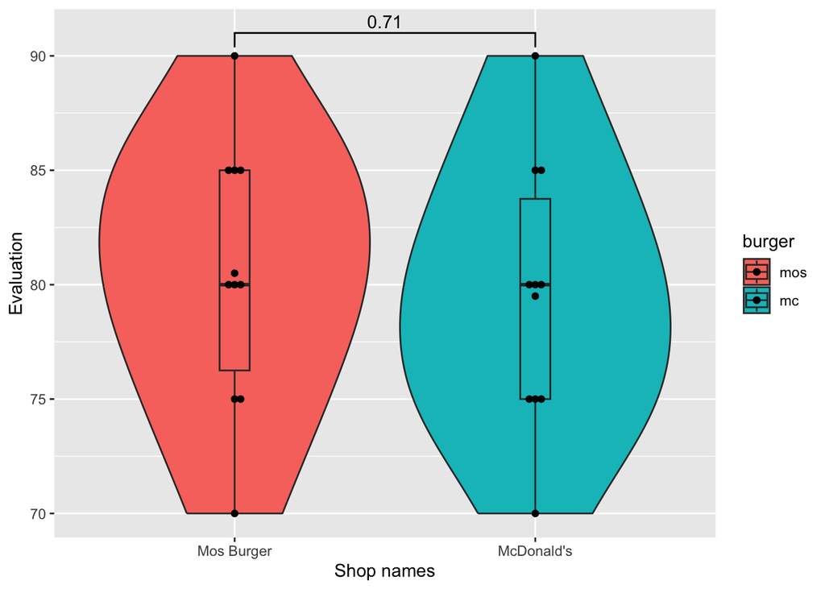

```r
df_long %>%
  mutate(burger = fct_inorder(burger)) %>%
  ggplot(aes(x = burger, y = score, fill = burger)) +
  geom_violin() +
  geom_boxplot(width = .1) + # 箱ひげ図の幅を 0.1 と指定
  stat_summary(fun.y = mean, geom = "point") + # 平均値を点で示す
    ggbeeswarm::geom_beeswarm() +
  scale_x_discrete(labels = c( "Mos Burger", "McDonald's")) +
  labs(x = "Shop names", y = "Evaluation") +
    ggsignif::geom_signif(comparisons = combn(sort(unique(df_long$burger)), 2, FUN = list),
                          test = "t.test",
                          na.rm = T,
                          step_increase = 0.1)
```

### 5.4.2 In case you use wide format data

```r
df_mos_mc
```

```
# A tibble: 10 × 2
     mos    mc
   <dbl> <dbl>
 1    80    75
 2    75    70
 3    80    80
 4    90    85
 5    85    90
 6    80    75
 7    75    85
 8    85    80
 9    85    80
10    70    75
```

```r
t.test(df_mos_mc$mos,
       df_mos_mc$mc) # unpaired is default
```

```
    Welch Two Sample t-test

data:  df_mos_mc$mos and df_mos_mc$mc
t = 0.37354, df = 18, p-value = 0.7131
alternative hypothesis: true difference in means is not equal to 0
95 percent confidence interval:
 -4.624301  6.624301
sample estimates:
mean of x mean of y
     80.5      79.5
```

- We get exactly the same result in Section 5.4.1 where we used `long format data`

# 6. Visualize the results by Bar Chart

- Recently, researchers tend to show their t-test results by bar chart in major academic journals in Social Sciences
- We use **a hypothetical survey data** on Mos Burgers and McDonald’s.
- `Unpaired-samples t-test`
- 20 people eat fried potatoes of **either Mos Burgers or McDonald’s.**
- Respondents 1 to 10 eat fried potato of Mos Burger.
- Respondents 11 to 20 eat fried potato McDonald’s burger.
- These 20 respondents evaluate them in 0 - 100 scale.
- What we want to know here:

**Which flied potatoes is better in tasts between Mos Burgers and McDonald’s**

[figure not shown]

## 6.1 Load `menu.csv`

- Load menu.csv and name it `df_menu`

```r
df_menu <- read_csv("data/menu.csv")
```

- Check the data

```r
DT::datatable(df_menu)
```

|  | mosmc | cheeseburger | fried_potato | teriyaki | shake |
| --- | --- | --- | --- | --- | --- |
| 1 | mos | 85 | 81 | 92 | 80 |
| 2 | mos | 88 | 71 | 90 | 83 |
| 3 | mos | 83 | 71 | 93 | 77 |
| 4 | mos | 87 | 74 | 93 | 72 |
| 5 | mos | 83 | 70 | 99 | 76 |
| 6 | mos | 81 | 75 | 94 | 79 |
| 7 | mos | 89 | 78 | 91 | 70 |
| 8 | mos | 78 | 78 | 93 | 82 |
| 9 | mos | 88 | 72 | 101 | 74 |
| 10 | mos | 93 | 77 | 97 | 68 |

[output cut: 10 more lines]

- `df_menu` is a `long format data`  
  => We can use the data as it is

## 6.2 t-test by R (long format data)

- `Unpaired-samples t-test`

```r
potato_ttest <- t.test(fried_potato ~ mosmc, data = df_menu)
potato_ttest
```

```
    Welch Two Sample t-test

data:  fried_potato by mosmc
t = 4.4463, df = 15.32, p-value = 0.0004489
alternative hypothesis: true difference in means between group mc and group mos is not equal to 0
95 percent confidence interval:
 3.233228 9.166772
sample estimates:
 mean in group mc mean in group mos
             80.9              74.7
```

## 6.3 Preparation to draw a bar chart

- Make a function and prepare for a data to draw a bar chart
- Make a function to define 95% confidence intervals (`mean_ci`)

```r
mean_ci <- function(data, by, vari){
    se <- function(x) sqrt(var(x)/length(x))
    meanci <- data %>%
        group_by({{by}}) %>%
        summarise(n = n(),
                  mean_out = mean({{vari}}),
                  se_out = se({{vari}}),
                  .group = "drop"
                  ) %>%
        mutate(
            lwr = mean_out - 1.96 * se_out,
            upr = mean_out + 1.96 * se_out
            ) %>%
        mutate(across(where(is.double), round, 1)) %>%
        mutate(mean_label = format(round(mean_out, 1), nsmall = 1)) %>%
        select({{by}}, mean_out, lwr, upr, mean_label) %>%
        mutate(across(.cols = {{by}}, as.factor))
    return(meanci)
}
```

- Using the function made above, let’s calculate the `mean` and `95% confidence intervals` of fried potatoes for Mos Burger and McDonald’s

```r
potato_mean <- df_menu %>%
  mean_ci(mosmc, fried_potato)

potato_mean
```

```
# A tibble: 2 × 5
  mosmc mean_out   lwr   upr mean_label
  <fct>    <dbl> <dbl> <dbl> <chr>
1 mc        80.9  79.4  82.4 80.9
2 mos       74.7  72.4  77   74.7
```

```r
potato_ttest <- t.test(fried_potato ~ mosmc, data = df_menu)
```

```r
potato_tidy <- tidy(potato_ttest) %>%
  select(estimate, p.value, conf.low, conf.high) %>%
  mutate(
    p_label = case_when(
      p.value <= 0.01 ~ "p < .01",
      p.value > 0.01 & p.value <= 0.05 ~ "p < .05",
      p.value > 0.05 & p.value <= 0.1 ~ "p < .1",
      p.value > 0.1 ~ "N.S"
      )
    )
```

- Merge the two data frame, `potato_mean` and `potato_tidy` by using `bind_cols()` function
- Name it `df_potato`
- Make a new variable, `mosmc`
- Make a new variable, `p_label`

```r
df_potato <- bind_cols(potato_mean, potato_tidy) %>%
  mutate(
    mosmc = as.factor(if_else(mosmc == "mc",
                              "McDonalds", "Mos Burger")),
    p_label = if_else(mosmc == "McDonalds", p_label, NA_character_),
    menu = "Fried Potato"
    )
```

- check `df_potato`

```r
df_potato
```

```
# A tibble: 2 × 11
  mosmc      mean_out   lwr   upr mean_label estimate p.value conf.low conf.high
  <fct>         <dbl> <dbl> <dbl> <chr>         <dbl>   <dbl>    <dbl>     <dbl>
1 McDonalds      80.9  79.4  82.4 80.9            6.2 4.49e-4     3.23      9.17
2 Mos Burger     74.7  72.4  77   74.7            6.2 4.49e-4     3.23      9.17
# ℹ 2 more variables: p_label <chr>, menu <chr>
```

- Show the bar chart using the data generated

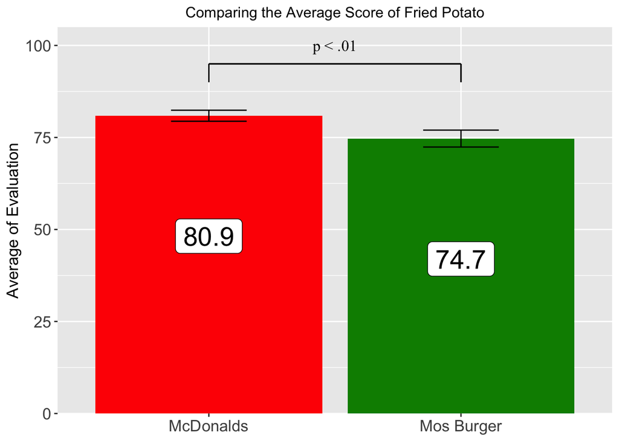

```r
pl_potato <- df_potato %>%
  ggplot(aes(x = mosmc, y = mean_out, fill = mosmc)) +
  geom_bar(stat = "identity") +
  geom_errorbar(aes(ymin = lwr, ymax = upr, width = 0.3)) +
  geom_label(aes(label = mean_label),
             size = 7.5, position = position_stack(vjust = 0.5),
    vjust = 4,
             show.legend = F, fill = "white") +
  geom_segment(aes(x = 1, y = 90, xend = 1, yend = 95)) +
  geom_segment(aes(x = 1, y = 95, xend = 2, yend = 95)) +
  geom_segment(aes(x = 2, y = 90, xend = 2, yend = 95)) +
  geom_text(aes(x = 1.5, y = 100, label = p_label),
            size = 4.5, family = "Times New Roman", inherit.aes = FALSE) +
  scale_fill_manual(values = c("red", "green4")) +
  scale_y_continuous(expand = c(0, 0),
                     limits = c(0, 105)) +
  labs(x = NULL, y = "Average of Evaluation",
       title = "Comparing the Average Score of Fried Potato") +
  theme(legend.position = "none",
        plot.title = element_text(size = 12, hjust = 0.5),
        axis.title = element_text(size = 13),
        axis.text = element_text(size = 13))

pl_potato
```

# 7. Visualize the results by difference

## 7.1 Data Preparation

```r
df_potato <- df_potato %>%
  mutate(across(where(is.double), ~ round(.x, 1))) %>%
  mutate(
    diff_x = "difference",
    diff_label = format(round(estimate, 1),
                        nsmall = 1)
    )
```

- Check the data

```r
df_potato
```

```
# A tibble: 2 × 13
  mosmc      mean_out   lwr   upr mean_label estimate p.value conf.low conf.high
  <fct>         <dbl> <dbl> <dbl> <chr>         <dbl>   <dbl>    <dbl>     <dbl>
1 McDonalds      80.9  79.4  82.4 80.9            6.2       0      3.2       9.2
2 Mos Burger     74.7  72.4  77   74.7            6.2       0      3.2       9.2
# ℹ 4 more variables: p_label <chr>, menu <chr>, diff_x <chr>, diff_label <chr>
```

- Visualize the average values with 95% confidence intervals

```r
pl_mean_poteto <- df_potato %>%
  ggplot(aes(x = mosmc,
             y = mean_out,
             ymin = lwr,
             ymax = upr)) +
  geom_pointrange(size = 1) +
  geom_text(aes(label = mean_label),
            size = 6.5,
            nudge_x = .13) +
  ylim(70, 100) +
  labs(x = NULL, y = NULL, title = "Average of Evaluation") +
  theme(plot.title  = element_text(hjust = 0.5, size = 16),
        axis.text = element_text(size = 17),
        panel.grid.major = element_blank(),
        panel.grid.minor = element_blank(),
        strip.background = element_blank(),
        strip.text.y = element_blank())
```

## 7.2 Visualize the difference between Mos and Mc

```r
pl_diff_poteto <- df_potato %>%
  ggplot(aes(x = diff_x, y = estimate)) +
  geom_hline(yintercept = 0, col = "red") +
  geom_pointrange(aes(ymin = conf.low, ymax = conf.high), size = 1) +
  geom_text(aes(label = diff_label),
            size = 6.5,
            nudge_x = .19) +
  labs(x = NULL, y = NULL, title = "difference") +
  theme(plot.title  = element_text(hjust = 0.5, size = 16),
        axis.text = element_text(size = 17),
        panel.grid.major = element_blank(),
        panel.grid.minor = element_blank(),
        strip.text.y = element_text(size = 17),
        strip.background = element_blank())
```

- Using `patchwork` package, show the results we get here

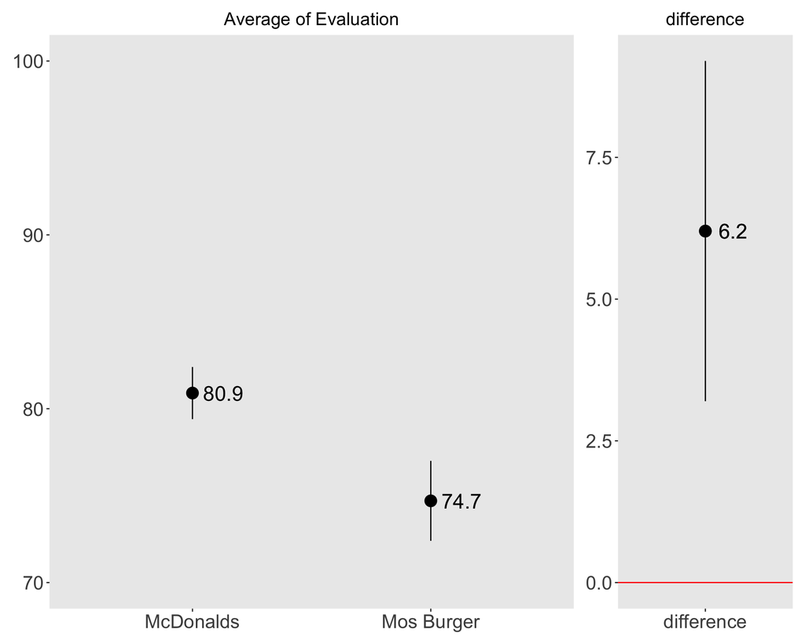

```r
pl_mean_diff <- pl_mean_poteto + pl_diff_poteto + plot_layout(widths = c(3, 1))

pl_mean_diff
```

## 7.3 Boxplot and Violin (diff)

[figure not shown]

```r
df_menu %>%
    ggplot(aes(mosmc, fried_potato, fill = mosmc)) +
    geom_violin() +
  geom_boxplot(width = .1) +
    stat_summary(fun.y = mean, geom = "point") +
  scale_x_discrete(labels = c( "Mos Burger", "McDonald's")) +
  labs(x = "Shop Name", y = "Evaluation") +
    ggsignif::geom_signif(comparisons = combn(sort(unique(df_menu$mosmc)), 2, FUN = list),
                          test = "t.test", na.rm = T,
                          step_increase = 0.1)
```

# 8. Exercise

## Exercise 8.1

- Using the general election data hr96-24.csv, we want to find out if there is a difference in the average vote share of the Liberal Democratic Party (LDP) and Komeito in the 2021 general election (single-member districts).

#### Q1:

- Write the null hypothesis for this test.

#### Q2:

- Write the alternative hypothesis for this test.

#### Q3:

- Use the `t.test()` function to output the test result, and explain the result in simple terms.

#### Q4:

- Create a boxplot + violin plot with the `geom_signif()` function to show the analysis results, including statistical significance.

#### Q5:

- Show the results of the t-test using a bar graph.

#### Q6:

- Show the results of the t-test using ‘difference’.

## Exercise 8.2

- There is fictional data ( menu.csv ) where 20 respondents rated ‘Cheeseburger’, ‘Fries’, ‘Teriyaki Burger’, and ‘Shake’ at Mos Burger and McDonald’s.
- Assume that 20 respondents ate all four types of food at either Mos Burger or McDonald’s.
- The question here is “Which is tastier for the ‘Cheeseburger’, Mos or Mc?”

#### Q1:

- Write the null hypothesis for this test.

#### Q2:

- Write the alternative hypothesis for this test.

#### Q3:

- Use the `t.test()` function to output the test result, and explain the result in simple terms.

#### Q4:

- Create a boxplot + violin plot with the `geom_signif()` function to show the analysis results, including statistical significance.

#### Q5:

- Show the results of the t-test using a bar graph.

#### Q6:

- Show the results of the t-test using ‘difference’.

## Exercise 8.3

- The following data is the test results (fictional data) of 30 students in a “Quantitative Analysis (Politics)” course: test_score.csv

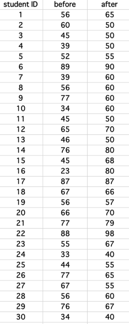

- The test results on the first day of class are shown as ‘before’, and those on the last day as ‘after’.
- The aim here is to find out through a t-test if the scores in quantitative political science improved as a result of attending the class.

#### Q1:

- Write the null hypothesis for this test.

#### Q2:

- Write the alternative hypothesis for this test.

#### Q3:

- Use the t.test() function to output the test result, and explain the result in simple terms.

#### Q4:

- Create a boxplot + violin plot with the `geom_signif()` function to show the analysis results, including statistical significance.

#### Q5:

- Show the results of the t-test using a bar graph.

#### Q6:

- Show the results of the t-test using ‘difference’.

## Exercise 8.4

- We want to investigate whether there is a difference in the ages (age) of candidates from the Liberal Democratic Party and the Constitutional Democratic Party in the 2021 general election.
- You can download the data [here](https://asanoucla.github.io/hr96-21.csv)

#### Q1:

- Write the null hypothesis for this test.

#### Q2:

- Write the alternative hypothesis for this test.

#### Q3:

- Use the `t.test()` function to output the test result, and explain the result in simple terms.

#### Q4:

- Create a boxplot + violin plot with the `geom_signif()` function to show the analysis results, including statistical significance.

#### Q5:

- Show the results of the t-test using a bar graph.

#### Q6:

- Show the results of the t-test using ‘difference’.

**Reference**

[宋財泫 (Jaehyun Song)- 矢内勇生 (Yuki Yanai)「私たちのR: ベストプラクティスの探究」](https://www.jaysong.net/RBook/)

グラフ作成に関しては遠藤勇哉氏（東北大学大学院情報科学研究科博士後期課程）の助言を参考にしています

[土井翔平（北海道大学公共政策大学院）「Rで計量政治学入門」](https://shohei-doi.github.io/quant_polisci/data-import.html)

[矢内勇生（高知工科大学）授業一覧](http://yukiyanai.github.io/teaching/)

浅野正彦, 矢内勇生.『Rによる計量政治学』オーム社、2018年

浅野正彦, 中村公亮.『初めてのRStudio』オーム社、2018年

Winston Chang, R Graphics Cookbook, O’Reilly Media, 2012.

Kieran Healy, DATA VISUALIZATION, Princeton, 2019

Kosuke Imai, Quantitative Social Science: An Introduction, Princeton University Press, 2017